# Project 3: Cars4U Project

There is a huge demand for used cars in the Indian Market today. As sales of new cars have slowed down in the recent past, the pre-owned car market has continued to grow over the past years and is larger than the new car market now. Cars4U is a budding tech start-up that aims to find footholes in this market.

In 2018-19, while new car sales were recorded at 3.6 million units, around 4 million second-hand cars were bought and sold. There is a slowdown in new car sales and that could mean that the demand is shifting towards the pre-owned market. In fact, some car sellers replace their old cars with pre-owned cars instead of buying new ones. Unlike new cars, where price and supply are fairly deterministic and managed by OEMs (Original Equipment Manufacturer / except for dealership level discounts which come into play only in the last stage of the customer journey), used cars are very different beasts with huge uncertainty in both pricing and supply. Keeping this in mind, the pricing scheme of these used cars becomes important in order to grow in the market.

As a senior data scientist at Cars4U, you have to come up with a pricing model that can effectively predict the price of used cars and can help the business in devising profitable strategies using differential pricing. For example, if the business knows the market price, it will never sell anything below it.

Objective

1. Explore and visualize the dataset.
2. Build a linear regression model to predict the prices of used cars.
3. Generate a set of insights and recommendations that will help the business.

Data Dictionary

1. S.No. : Serial Number
2. Name : Name of the car which includes Brand name and Model name
3. Location : The location in which the car is being sold or is available for purchase Cities
4. Year : Manufacturing year of the car
5. Kilometers_driven : The total kilometers driven in the car by the previous owner(s) in KM.
6. Fuel_Type : The type of fuel used by the car. (Petrol, Diesel, Electric, CNG, LPG)
7. Transmission : The type of transmission used by the car. (Automatic / Manual)
8. Owner : Type of ownership
9. Mileage : The standard mileage offered by the car company in kmpl or km/kg
10. Engine : The displacement volume of the engine in CC.
11. Power : The maximum power of the engine in bhp.
12. Seats : The number of seats in the car.
13. New_Price : The price of a new car of the same model in INR Lakhs.(1 Lakh = 100, 000)
14. Price : The price of the used car in INR Lakhs (1 Lakh = 100, 000)

## Import Libraries

```python
# Import necessary libraries.
import warnings

warnings.filterwarnings("ignore")

import numpy as np
import pandas as pd
import matplotlib.pyplot as plt
import seaborn as sns
import statsmodels.api as sm

# Removes the limit for the number of displayed columns
pd.set_option("display.max_columns", None)
# Sets the limit for the number of displayed rows
pd.set_option("display.max_rows", 200)

# To enable plotting graphs in Jupyter notebook
%matplotlib inline

# To build linear regression_model
from sklearn.linear_model import LinearRegression

# To check model performance
from sklearn.metrics import mean_absolute_error, mean_squared_error, r2_score
```

# Loading and exploring the data

```python
df = pd.read_csv("C:/Users/Konto/Documents/ESTUDOS/Texas university/BEST OF PHYTON/used_cars_data.csv", engine="python")

# The Data has a lot of information which provide us some security about deleting or changing values
print(f"There are {df.shape[0]} rows and {df.shape[1]} columns.")
```

```
There are 7253 rows and 14 columns.
```

```python
np.random.seed(8)
df.head(10)
```

|  | S.No. | Name | Location | Year | Kilometers_Driven | Fuel_Type | Transmission | Owner_Type | Mileage | Engine | Power | Seats | New_Price | Price |
| --- | --- | --- | --- | --- | --- | --- | --- | --- | --- | --- | --- | --- | --- | --- |
| 0 | 0 | Maruti Wagon R LXI CNG | Mumbai | 2010 | 72000 | CNG | Manual | First | 26.6 km/kg | 998 CC | 58.16 bhp | 5.0 | NaN | 1.75 |
| 1 | 1 | Hyundai Creta 1.6 CRDi SX Option | Pune | 2015 | 41000 | Diesel | Manual | First | 19.67 kmpl | 1582 CC | 126.2 bhp | 5.0 | NaN | 12.50 |
| 2 | 2 | Honda Jazz V | Chennai | 2011 | 46000 | Petrol | Manual | First | 18.2 kmpl | 1199 CC | 88.7 bhp | 5.0 | 8.61 Lakh | 4.50 |
| 3 | 3 | Maruti Ertiga VDI | Chennai | 2012 | 87000 | Diesel | Manual | First | 20.77 kmpl | 1248 CC | 88.76 bhp | 7.0 | NaN | 6.00 |
| 4 | 4 | Audi A4 New 2.0 TDI Multitronic | Coimbatore | 2013 | 40670 | Diesel | Automatic | Second | 15.2 kmpl | 1968 CC | 140.8 bhp | 5.0 | NaN | 17.74 |
| 5 | 5 | Hyundai EON LPG Era Plus Option | Hyderabad | 2012 | 75000 | LPG | Manual | First | 21.1 km/kg | 814 CC | 55.2 bhp | 5.0 | NaN | 2.35 |
| 6 | 6 | Nissan Micra Diesel XV | Jaipur | 2013 | 86999 | Diesel | Manual | First | 23.08 kmpl | 1461 CC | 63.1 bhp | 5.0 | NaN | 3.50 |
| 7 | 7 | Toyota Innova Crysta 2.8 GX AT 8S | Mumbai | 2016 | 36000 | Diesel | Automatic | First | 11.36 kmpl | 2755 CC | 171.5 bhp | 8.0 | 21 Lakh | 17.50 |
| 8 | 8 | Volkswagen Vento Diesel Comfortline | Pune | 2013 | 64430 | Diesel | Manual | First | 20.54 kmpl | 1598 CC | 103.6 bhp | 5.0 | NaN | 5.20 |
| 9 | 9 | Tata Indica Vista Quadrajet LS | Chennai | 2012 | 65932 | Diesel | Manual | Second | 22.3 kmpl | 1248 CC | 74 bhp | 5.0 | NaN | 1.95 |

```python
df.info()
# Serial Number is the same as the index column. No need to do analysis on this column, since it does not provide valuable information
# Name is a string and has many different values within the data....column to be split (Brand, Label) and analysed
# Location, Fuel Type, Transmission, Owner_Type are variables with few unique values, they can be treated as strings.
# Mileage, Engine, Power, Seats, Price need to be aligned as numerical values with the same 'standards'
# New_Price column to be deleted since it has over 85% of missing data
```

```
<class 'pandas.core.frame.DataFrame'>
RangeIndex: 7253 entries, 0 to 7252
Data columns (total 14 columns):
 #   Column             Non-Null Count  Dtype
---  ------             --------------  -----
 0   S.No.              7253 non-null   int64
 1   Name               7253 non-null   object
 2   Location           7253 non-null   object
 3   Year               7253 non-null   int64
 4   Kilometers_Driven  7253 non-null   int64
 5   Fuel_Type          7253 non-null   object
 6   Transmission       7253 non-null   object
 7   Owner_Type         7253 non-null   object
 8   Mileage            7251 non-null   object
 9   Engine             7207 non-null   object
 10  Power              7207 non-null   object
 11  Seats              7200 non-null   float64
 12  New_Price          1006 non-null   object
 13  Price              6019 non-null   float64
dtypes: float64(2), int64(3), object(9)
memory usage: 793.4+ KB
```

```python
df.isnull().sum() # columns missing values
# As mentioned before column New_Price will be deleted.
# After some transformation from object to numerical, we will to do further adjustments.
# The Mileage, Engine and Power rows with missing data can be deleted, since there are few rows.
```

```
S.No.                   0
Name                    0
Location                0
Year                    0
Kilometers_Driven       0
Fuel_Type               0
Transmission            0
Owner_Type              0
Mileage                 2
Engine                 46
Power                  46
Seats                  53
New_Price            6247
Price                1234
dtype: int64
```

```python
num_missing = df.isnull().sum(axis=1) # rows missing values
num_missing.value_counts()
# The rows with one missing values are probably found in the column New_Price ,while the rows with two missing values in column New_Price and Price.
```

```
1    5335
2    1048
0     823
4      36
5      10
3       1
dtype: int64
```

```python
num_missing = df.isnull().sum(axis=1)
num_missing.value_counts()
df[num_missing == 4].sample(n=10)
# The columns Engine, Power, Seats can be easily excluded from the data set, when values are missing. Most of them lack information all together.
```

|  | S.No. | Name | Location | Year | Kilometers_Driven | Fuel_Type | Transmission | Owner_Type | Mileage | Engine | Power | Seats | New_Price | Price |
| --- | --- | --- | --- | --- | --- | --- | --- | --- | --- | --- | --- | --- | --- | --- |
| 194 | 194 | Honda City 1.5 GXI | Ahmedabad | 2007 | 60006 | Petrol | Manual | First | 0.0 kmpl | NaN | NaN | NaN | NaN | 2.95 |
| 3810 | 3810 | Honda CR-V AT With Sun Roof | Kolkata | 2013 | 27000 | Petrol | Automatic | First | 14.0 kmpl | NaN | NaN | NaN | NaN | 11.99 |
| 4011 | 4011 | Fiat Punto 1.3 Emotion | Pune | 2011 | 45271 | Diesel | Manual | First | 20.3 kmpl | NaN | NaN | NaN | NaN | 2.60 |
| 2325 | 2325 | Maruti Swift 1.3 VXI ABS | Pune | 2015 | 67000 | Petrol | Manual | First | 16.1 kmpl | NaN | NaN | NaN | NaN | 4.70 |
| 4577 | 4577 | BMW 5 Series 520d Sedan | Delhi | 2012 | 72000 | Diesel | Automatic | Third | 18.48 kmpl | NaN | NaN | NaN | NaN | 13.85 |
| 208 | 208 | Maruti Swift 1.3 VXi | Kolkata | 2010 | 42001 | Petrol | Manual | First | 16.1 kmpl | NaN | NaN | NaN | NaN | 2.11 |
| 2780 | 2780 | Hyundai Santro GLS II - Euro II | Pune | 2009 | 100000 | Petrol | Manual | First | 0.0 kmpl | NaN | NaN | NaN | NaN | 1.60 |
| 3520 | 3520 | BMW 5 Series 520d Sedan | Delhi | 2012 | 90000 | Diesel | Automatic | First | 18.48 kmpl | NaN | NaN | NaN | NaN | 14.50 |
| 1460 | 1460 | Land Rover Range Rover Sport 2005 2012 Sport | Coimbatore | 2008 | 69078 | Petrol | Manual | First | 0.0 kmpl | NaN | NaN | NaN | NaN | 40.88 |
| 3522 | 3522 | Hyundai Santro GLS II - Euro II | Kochi | 2012 | 66400 | Petrol | Manual | First | 0.0 kmpl | NaN | NaN | NaN | NaN | 2.66 |

```python
for n in num_missing.value_counts().sort_index().index:
    if n > 0:
        print(f'For the rows with exactly {n} missing values, NAs are found in:')
        n_miss_per_col = df[num_missing == n].isnull().sum()
        print(n_miss_per_col[n_miss_per_col > 0])
        print('\n\n')
```

```
For the rows with exactly 1 missing values, NAs are found in:
Mileage         1
New_Price    5152
Price         182
dtype: int64



For the rows with exactly 2 missing values, NAs are found in:
Mileage         1
Seats           6
New_Price    1048
Price        1041
dtype: int64



For the rows with exactly 3 missing values, NAs are found in:
Seats        1
New_Price    1
Price        1
dtype: int64



For the rows with exactly 4 missing values, NAs are found in:
Engine       36
Power        36
Seats        36
New_Price    36
dtype: int64



For the rows with exactly 5 missing values, NAs are found in:
Engine       10
Power        10
Seats        10
New_Price    10
Price        10
dtype: int64
```

```python
df.Location.value_counts()
# City categorical values well distributed
```

```
Mumbai        949
Hyderabad     876
Kochi         772
Coimbatore    772
Pune          765
Delhi         660
Kolkata       654
Chennai       591
Jaipur        499
Bangalore     440
Ahmedabad     275
Name: Location, dtype: int64
```

```python
df.Fuel_Type.value_counts()
# Fuel type variable has only few data for CNG, LPG and Electric, which will not provide reliable information about these fuel types.
# Indian market is also not mature enough for these Fuel Types.
# I will delete these rows later
```

```
Diesel      3852
Petrol      3325
CNG           62
LPG           12
Electric       2
Name: Fuel_Type, dtype: int64
```

```python
df.Transmission.value_counts()
# Enough information about transmission variables
```

```
Manual       5204
Automatic    2049
Name: Transmission, dtype: int64
```

```python
df.Owner_Type.value_counts()
# Owner_type has large number of data on First and Second, though few data sets on other variables.
# I will delete the rows for 'Fourth & Above' later
```

```
First             5952
Second            1152
Third              137
Fourth & Above      12
Name: Owner_Type, dtype: int64
```

```python
df.Seats.value_counts()
# Enough information about Seats values, but there is one observation for seats zero, which makes no sense.
```

```
5.0     6047
7.0      796
8.0      170
4.0      119
6.0       38
2.0       18
10.0       8
9.0        3
0.0        1
Name: Seats, dtype: int64
```

# Processing columns

### Changing file name

```python
CARS = df.copy() #I prefer to change the file name because if I test different processing,I dont have to run everything again, just his piece downward.
```

### Droping columns, missing values and duplicates

```python
# Column New_Price: Since this column has more than 85% of the data missing, the information is no longer reliable
# The use of this column will generate incorrect results to the model, as it is artificially inflating the model.
CARS.drop(['New_Price','S.No.'], axis=1, inplace=True)
```

```python
# since we have enough data, it is possible to remove the rows of data which have missing value(s) seens above
CARS = CARS.dropna()
```

```python
CARS.drop_duplicates(inplace=True)
```

```python
CARS.info() # after droping null values and duplicates, the data still has enough values
```

```
<class 'pandas.core.frame.DataFrame'>
Int64Index: 5975 entries, 0 to 6018
Data columns (total 12 columns):
 #   Column             Non-Null Count  Dtype
---  ------             --------------  -----
 0   Name               5975 non-null   object
 1   Location           5975 non-null   object
 2   Year               5975 non-null   int64
 3   Kilometers_Driven  5975 non-null   int64
 4   Fuel_Type          5975 non-null   object
 5   Transmission       5975 non-null   object
 6   Owner_Type         5975 non-null   object
 7   Mileage            5975 non-null   object
 8   Engine             5975 non-null   object
 9   Power              5975 non-null   object
 10  Seats              5975 non-null   float64
 11  Price              5975 non-null   float64
dtypes: float64(2), int64(2), object(8)
memory usage: 606.8+ KB
```

### Transforming columns with strings into numerical values

```python
# Transform the Column Engine into Float. No need to make calculations, since all measures are in "CC"
def Mil(Engine):
    if isinstance(Engine, str):
        return float(Engine.replace('CC', ''))
    else:
        return np.nan

col_transforms = {
    'Engine': Mil
}

for k,v in col_transforms.items():
    CARS[k] = CARS[k].map(v)
```

```python
# Transform the Column Power into Float. No need to make calculations, since all measures are in "bhp"

CARS['Power'] = CARS['Power'].str.replace('bhp', '').str.replace('null','')
CARS['Power'] = pd.to_numeric(CARS['Power'], errors='coerce')
```

```python
# Transform the Column Mileage into Float. No need to make calculations, since measures are comparable.
CARS['Mileage'] = CARS['Mileage'].str.replace('kmpl', '').str.replace('km/kg','')
CARS['Mileage'] = pd.to_numeric(CARS['Mileage'], errors='coerce')
```

```python
# All necessary columns are numerical, but the column Power lost some information due to transformation.
CARS.info()
```

```
<class 'pandas.core.frame.DataFrame'>
Int64Index: 5975 entries, 0 to 6018
Data columns (total 12 columns):
 #   Column             Non-Null Count  Dtype
---  ------             --------------  -----
 0   Name               5975 non-null   object
 1   Location           5975 non-null   object
 2   Year               5975 non-null   int64
 3   Kilometers_Driven  5975 non-null   int64
 4   Fuel_Type          5975 non-null   object
 5   Transmission       5975 non-null   object
 6   Owner_Type         5975 non-null   object
 7   Mileage            5975 non-null   float64
 8   Engine             5975 non-null   float64
 9   Power              5872 non-null   float64
 10  Seats              5975 non-null   float64
 11  Price              5975 non-null   float64
dtypes: float64(5), int64(2), object(5)
memory usage: 606.8+ KB
```

# Exploratory Data Analysis and Data Treatment

```python
cars = CARS.copy()
```

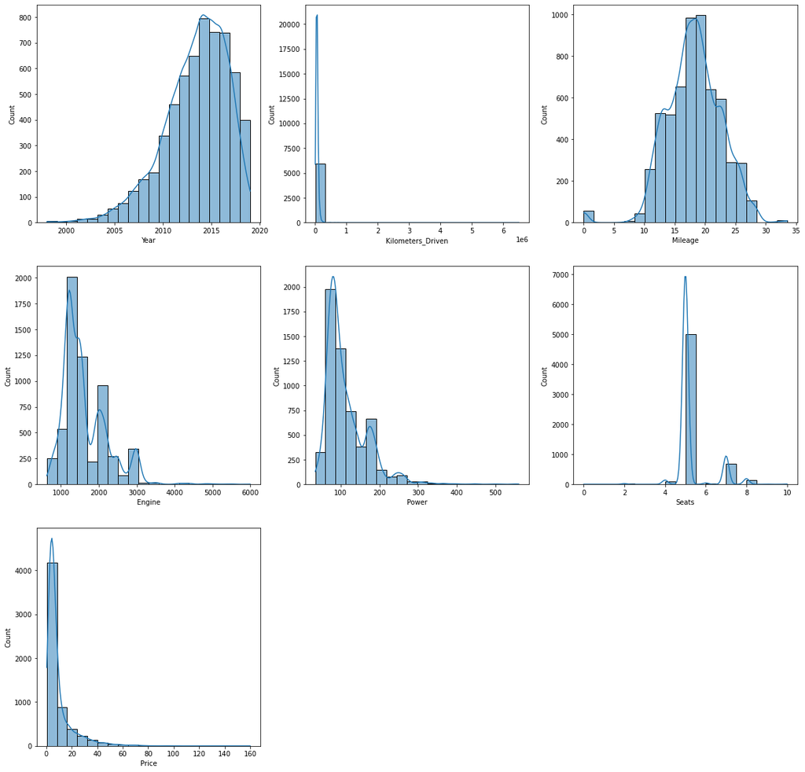

```python
# lets plot histogram of all numerical variables

all_col = cars.select_dtypes(include=np.number).columns.tolist()
plt.figure(figsize=(20, 20))

for i in range(len(all_col)):
    plt.subplot(3, 3, i + 1)
    sns.histplot(cars[all_col[i]], bins = 20, kde=True)  # you can comment the previous line and run this one to get distribution curves

plt.show()
```

Kilometers_Driven and Price have very skewed data to the right due to few outliers, which can be seem more clearly below.

Engine and Power are also skewed to the right, but a bit less. Year is skewed to the left.

Seats shows an extremely number of data at 5 and very few in other values.

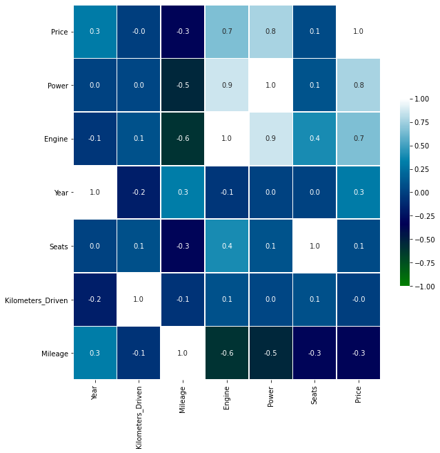

```python
# Correlation is much higher between Price/Power, as well as Price/Engine
numeric_columns = cars.select_dtypes(include=np.number).columns.tolist()
corr = (
    cars[numeric_columns].corr().sort_values(by=["Price"], ascending=False)
)

f, ax = plt.subplots(figsize=(10, 10))

sns.heatmap(
    corr,
    cmap="ocean",
    annot=True,
    fmt=".1f",
    vmin=-1,
    vmax=1,
    center=0,
    square=False,
    linewidths=0.7,
    cbar_kws={"shrink": 0.5},
)
```

The correlation graph shows that the price has higher correlation with Engine and Power.

While Engine and Power have almost perfect correlation. That implies a Multicolinearity between these variables and will affect the VIF.

One of the variables can be deleted before the statistical analysis or during the analysis. I will delet Engine, because it has a lower correlation with price and the VIF is higher.

All other correlations are smaller and there are few negative correlations.

```python
def histogram_boxplot(feature, figsize=(10, 6), bins=None):
    sns.set(font_scale=2)  # setting the font scale for seaborn
    f2, (ax_box2, ax_hist2) = plt.subplots(
        nrows=2,  # Number of rows of the subplot grid=2
        sharex=True,  # x-axis will be shared among all subplots
        gridspec_kw={"height_ratios": (0.25, 0.75)},
        figsize=figsize,
    )  # creating the 2 subplots
    sns.boxplot(
        feature, ax=ax_box2, showmeans=True, color="red"
    )  # boxplot will be created and a star will indicate the mean value of the column
    sns.distplot(feature, kde=F, ax=ax_hist2, bins=bins) if bins else sns.distplot(
        feature, kde=False, ax=ax_hist2
    )  # For histogram
    ax_hist2.axvline(
        feature.mean(), color="g", linestyle="--"
    )  # Add mean to the histogram
    ax_hist2.axvline(
        feature.median(), color="black", linestyle="-"
    )  # Add median to the histogram
```

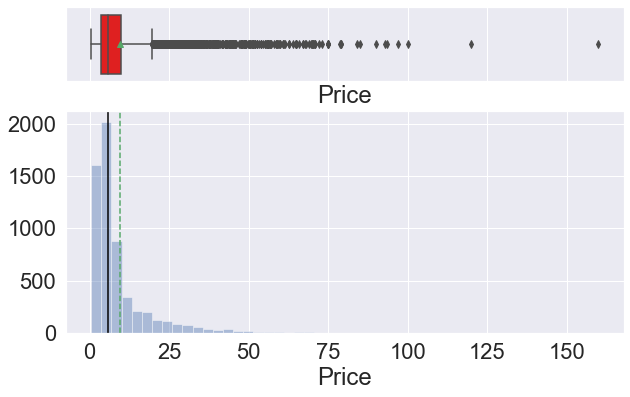

```python
histogram_boxplot(cars["Price"])
# The price is skiwed to the right. There are a lot of outliers in the data.
```

```python
cars['Price'].describe()
# Mean, Median and Mode are very distant. Hence the data has a huge spread itself (0.44 - 160), the dispersion values reflect this.
```

```
count    5975.000000
mean        9.501647
std        11.205736
min         0.440000
25%         3.500000
50%         5.650000
75%         9.950000
max       160.000000
Name: Price, dtype: float64
```

```python
cars['Price'].mode()
```

```
0    4.5
dtype: float64
```

```python
quartiles = np.quantile(cars['Price'][cars['Price'].notnull()], [.25, .75])
power_Xiqr = 5 * (quartiles[1] - quartiles[0])
print(f'Q1 = {quartiles[0]}, Q3 = {quartiles[1]}, 5*IQR = {power_Xiqr}')
outlier_PRICE = cars.loc[np.abs(cars['Price'] - cars['Price'].median()) > power_Xiqr, 'Price']
outlier_PRICE.count()
```

```
Q1 = 3.5, Q3 = 9.95, 5*IQR = 32.25
```

```
210
```

### Based on several tests made for the statistical model, the best solution turned out to be a level of 5 x IQR for Outliers acceptance.

### Also different analysis done in all variables and only in the three 'extreme' variables showed that the statistical model worked better for the 3 extremes.